# `data.table` Case Study - Women in Parliament

Saghir Bashir

Tue 22 Jun 2021 (16:21:37)

# Case Study: Women in Parliament

# Objectives

*Explore the geographical and time trends for the percentage of women in national parliaments.*

## Questions

The objective is to look at the geographical and time trends in the data. We will answer the following questions.

- What are the time trends for Portugal?
- How does Portugal compare to other countries?
- Which countries have the highest percentage of women in parliament by year?
- How do continents compare?
- What are the global trends over time?

# Data Details

The raw data for *“Proportion of seats held by women in national parliaments”* includes the percentage of women in parliament (*“single or lower parliamentary chambers only”*) by country (region) and year. It can be downloaded from:

- https://data.worldbank.org/indicator/SG.GEN.PARL.ZS

As part of its “open data” mission the World Bank offers *“free and open access to global development data”* kindly licensed under the “Creative Commons Attribution 4.0 (CC-BY 4.0)”.

## Source Data

The data originates from the “Inter-Parliamentary Union” (IPU) which provides an *“Archive of statistical data on the percentage of women in national parliaments”* going back to 1997 on a monthly basis:

- http://archive.ipu.org/wmn-e/classif-arc.htm

The World Bank data is for “single or lower parliamentary chambers only”, while the IPU also presents data for “Upper Houses or Senates”. Moreover, the IPU provides the actual numbers used to calculate the percentages (which the World Bank does not).

## Data limitations

Take caution when interpreting these data, as parliamentary systems vary from country to country, and in some cases over time. Some of the issues to consider include:

- Who has, and who does not have, the right to become a Member of Parliament (MP)?
- How does someone become an MP? Through democratic elections? How is “democratic election” defined?
- What is the real power of MPs and their parliament? Can MPs make a difference?

## Data definitions & assumptions

### “Women”

The definition for “women” is not given, so we will assume that it refers to a binary classification for gender (sex).

### “Country (Region)”

The definition of countries and regions can change over time. (e.g. formation of new countries after conflicts, new member states joining a pre-existing collective). How are these changes reflected in the data? How do they affect the interpretation?

For example, the “European Union” has changed over time. It started in the 1950s as a block of six European countries (known as the “European Community”) and has expanded over the years to 28 countries (with the United Kingdom about to depart). This raises the question of how the European Union average is calculated. For a given year, is it calculated based on the actual member states in that year or on all of the current member states?

## World Bank Datasets

The World Banks provides the following data files.

```r
wbFiles <- list.files(here("data"), full.names = FALSE)
indData <- wbFiles[grepl("^API", wbFiles)]
indMeta <- wbFiles[grepl("Indicator", wbFiles)]
ctyMeta <- wbFiles[grepl("Country", wbFiles)]
```

- “**API_SG.GEN.PARL.ZS_DS2_en_csv_v2_2163427.csv**” contains the “Proportion of seats held by women in national parliaments (%)” data.
- “**Metadata_Indicator_API_SG.GEN.PARL.ZS_DS2_en_csv_v2_2163427.csv**” contains the indicator meta data which is as described above.
- “**Metadata_Country_API_SG.GEN.PARL.ZS_DS2_en_csv_v2_2163427.csv**” contains the Country related meta data that can be useful to understand the limitations of the data by country.

# Data Processing

The World Bank’s “Women in Parliament” data are imported and undergo some “tidying” before being used for the analyses in the sections below.

```r
wip <- fread(here("data", indData),
            skip = 4, header = TRUE,
            check.names = TRUE)

# Add Continent to WiP dataset.
cl <- as.data.table(codelist)[, .(continent, wb)]

wipcl <- merge(wip, cl, by.x = "Country.Code", by.y = "wb", all.x = TRUE)
setnames(wipcl, c("continent"), c("Continent"))

WP <- melt(wipcl,
           id.vars = c("Continent", "Country.Name", "Country.Code", "Indicator.Code"),
           measure = patterns("^X"),
           variable.name = "YearC",
           value.name = c("pctWiP"),
           na.rm = TRUE)

# Note cLabel will be used to label the ends of lines in plots.
WP[, `:=`(Year = as.numeric(gsub("^X", "", YearC)), Ratio = (100 - pctWiP)/pctWiP)][
  , fYear := factor(Year)][
  , maxYear:=max(Year), by = .(Country.Name)][
    Year==maxYear, cLabel:=Country.Name][
      , c("maxYear", "YearC"):=NULL]

setcolorder(WP, c("Indicator.Code", "Continent", "Country.Name", "Country.Code",
                  "Year", "pctWiP", "Ratio"))
setkeyv(WP, c("Indicator.Code", "Continent", "Country.Name", "Country.Code", "Year"))

WP
```

```
##       Indicator.Code Continent Country.Name Country.Code Year   pctWiP    Ratio
##    1: SG.GEN.PARL.ZS      <NA>   Arab World          ARB 1997 3.747161 25.68687
##    2: SG.GEN.PARL.ZS      <NA>   Arab World          ARB 1998 3.457447 27.92308
##    3: SG.GEN.PARL.ZS      <NA>   Arab World          ARB 1999 3.616776 26.64894
##    4: SG.GEN.PARL.ZS      <NA>   Arab World          ARB 2000 3.770681 25.52041
##    5: SG.GEN.PARL.ZS      <NA>   Arab World          ARB 2001 4.621265 20.63910
##   ---
## 5387: SG.GEN.PARL.ZS   Oceania      Vanuatu          VUT 2016 0.000000      Inf
## 5388: SG.GEN.PARL.ZS   Oceania      Vanuatu          VUT 2017 0.000000      Inf
## 5389: SG.GEN.PARL.ZS   Oceania      Vanuatu          VUT 2018 0.000000      Inf
## 5390: SG.GEN.PARL.ZS   Oceania      Vanuatu          VUT 2019 0.000000      Inf
## 5391: SG.GEN.PARL.ZS   Oceania      Vanuatu          VUT 2020 0.000000      Inf
##       fYear  cLabel
##    1:  1997    <NA>
##    2:  1998    <NA>
##    3:  1999    <NA>
##    4:  2000    <NA>
##    5:  2001    <NA>
##   ---
## 5387:  2016    <NA>
## 5388:  2017    <NA>
## 5389:  2018    <NA>
## 5390:  2019    <NA>
## 5391:  2020 Vanuatu
```

# Analysis

## Portugal - Trends and Comparisons

> What are the time trends for Portugal?

Let’s start by looking at a plot of how Portugal is performing over time.

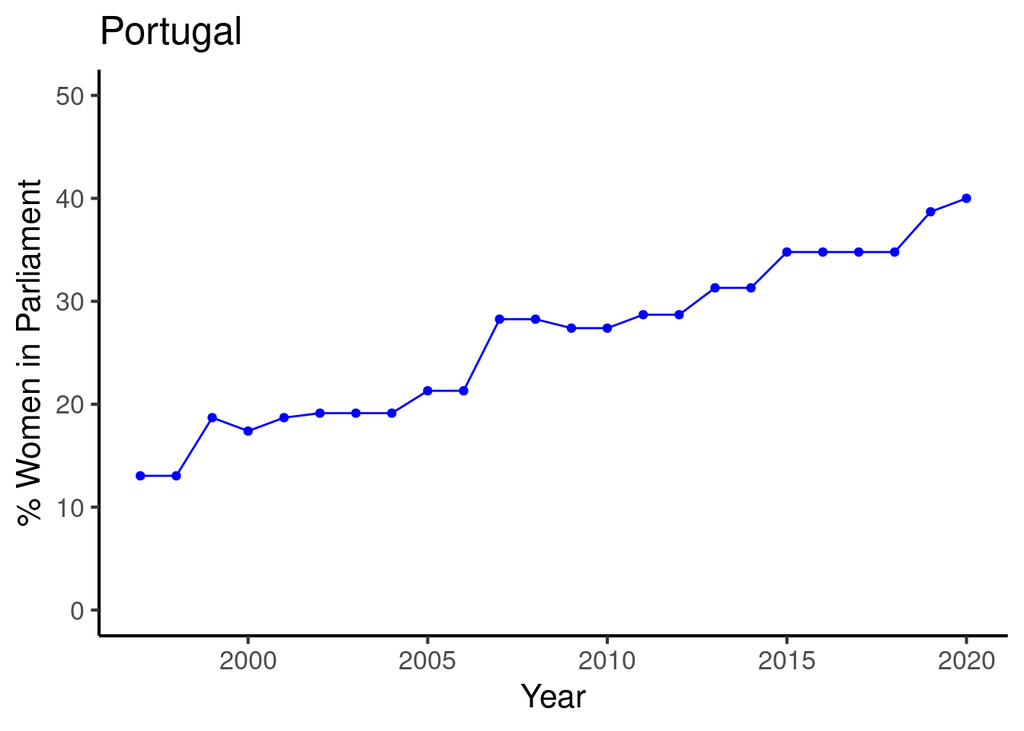

```r
WP[Country.Name %in% "Portugal"] %>%
ggplot(aes(Year, pctWiP)) +
  geom_line(colour = "blue") +
  geom_point(colour = "blue") +
  scale_x_continuous(breaks=seq(1990, 2020, 5)) +
  scale_y_continuous(limits=c(0, 50)) +
  ggtitle("Portugal") +
  xlab("Year") +
  ylab("% Women in Parliament")
```

**Interpretation**

Let’s now plot how Portugal compares with other European countries. As a reference the European Union and World averages. Finland, Hungary, Sweden and Romania are highlighted for discussion.

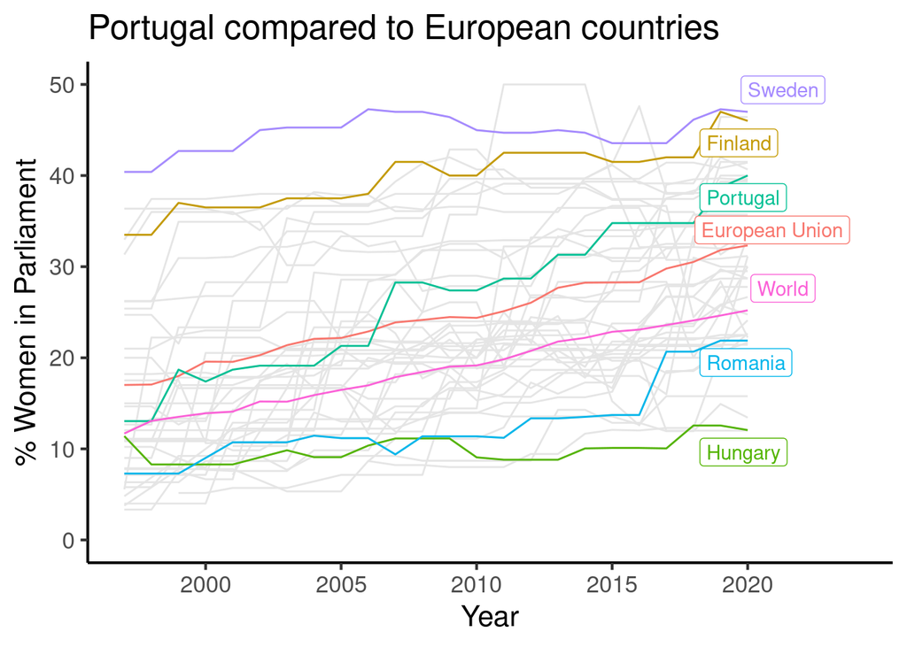

```r
WP[Continent == "Europe"] %>%
  ggplot(aes(Year, pctWiP, group=Country.Name, colour = Country.Name, label = cLabel)) +
  geom_line(colour="grey90") +
  geom_line(data = WP[Country.Name %in% c("Portugal", "European Union", "World",
                                          "Sweden", "Finland", "Hungary", "Romania")],
            aes(colour = Country.Name)) +
  scale_x_continuous(breaks=seq(1990, 2024, 5)) +
  scale_y_continuous(limits=c(0, 50), breaks=seq(0, 50, by=10)) +
  expand_limits(x = 2024) +
  geom_label_repel(data = WP[Country.Name %in% c("Portugal", "European Union", "World",
                                                 "Sweden", "Finland", "Hungary", "Romania")],
                   xlim = c(2018, 2024)) +
  theme(legend.position = "none") +
  ggtitle("Portugal compared to European countries") +
  xlab("Year") +
  ylab("% Women in Parliament")
```

**Interpretation**

## Highest Percentages

> Which countries have the highest percentage of women in parliament by year? How do continents compare?

```r
hgWiP <- WP[!is.na(Continent)][
  order(Continent, Year, -pctWiP), head(.SD, 1), by = .(Continent, Year)][
  , CountryWiP := sprintf("%3.1f%% - %s", pctWiP, Country.Name)][
  , .(Continent, Year, CountryWiP)]

hgCont <- dcast(hgWiP, Year ~ Continent, value.var = "CountryWiP")

hgCont %>%
  kable(align="clllll") %>%
  kable_styling(bootstrap_options = "striped")
```

| Year | Africa | Americas | Asia | Europe | Oceania |
| --- | --- | --- | --- | --- | --- |
| 1997 | 27.3% - Seychelles | 27.6% - Argentina | 26.2% - Vietnam | 40.4% - Sweden | 29.2% - New Zealand |
| 1998 | 28.8% - South Africa | 27.6% - Argentina | 26.2% - Vietnam | 40.4% - Sweden | 29.2% - New Zealand |
| 1999 | 30.0% - South Africa | 27.6% - Cuba | 26.0% - Vietnam | 42.7% - Sweden | 29.2% - New Zealand |
| 2000 | 30.0% - Mozambique | 27.6% - Cuba | 26.0% - Turkmenistan | 42.7% - Sweden | 30.8% - New Zealand |
| 2001 | 30.0% - Mozambique | 27.6% - Cuba | 26.0% - Turkmenistan | 42.7% - Sweden | 30.8% - New Zealand |
| 2002 | 30.0% - Mozambique | 35.1% - Costa Rica | 27.3% - Vietnam | 45.0% - Sweden | 29.2% - New Zealand |
| 2003 | 48.8% - Rwanda | 36.0% - Cuba | 27.3% - Vietnam | 45.3% - Sweden | 28.3% - New Zealand |
| 2004 | 48.8% - Rwanda | 36.0% - Cuba | 27.3% - Vietnam | 45.3% - Sweden | 28.3% - New Zealand |
| 2005 | 48.8% - Rwanda | 36.2% - Argentina | 27.3% - Afghanistan | 45.3% - Sweden | 32.2% - New Zealand |
| 2006 | 48.8% - Rwanda | 38.6% - Costa Rica | 27.3% - Afghanistan | 47.3% - Sweden | 32.2% - New Zealand |
| 2007 | 48.8% - Rwanda | 40.0% - Argentina | 29.2% - Timor-Leste | 47.0% - Sweden | 33.1% - New Zealand |
| 2008 | 56.2% - Rwanda | 43.2% - Cuba | 33.2% - Nepal | 47.0% - Sweden | 33.6% - New Zealand |
| 2009 | 56.2% - Rwanda | 43.2% - Cuba | 33.2% - Nepal | 46.4% - Sweden | 33.6% - New Zealand |
| 2010 | 56.2% - Rwanda | 43.2% - Cuba | 33.2% - Nepal | 45.0% - Sweden | 33.6% - New Zealand |
| 2011 | 56.2% - Rwanda | 45.2% - Cuba | 33.2% - Nepal | 50.0% - Andorra | 32.2% - New Zealand |
| 2012 | 56.2% - Rwanda | 45.2% - Cuba | 38.5% - Timor-Leste | 50.0% - Andorra | 32.2% - New Zealand |
| 2013 | 63.8% - Rwanda | 48.9% - Cuba | 38.5% - Timor-Leste | 50.0% - Andorra | 32.2% - New Zealand |
| 2014 | 63.8% - Rwanda | 53.1% - Bolivia | 38.5% - Timor-Leste | 50.0% - Andorra | 29.8% - New Zealand |
| 2015 | 63.8% - Rwanda | 53.1% - Bolivia | 38.5% - Timor-Leste | 43.6% - Sweden | 31.4% - New Zealand |
| 2016 | 63.8% - Rwanda | 53.1% - Bolivia | 38.5% - Timor-Leste | 47.6% - Iceland | 31.4% - New Zealand |
| 2017 | 61.2% - Rwanda | 53.1% - Bolivia | 32.3% - Timor-Leste | 43.6% - Sweden | 38.3% - New Zealand |
| 2018 | 61.2% - Rwanda | 53.2% - Cuba | 33.8% - Timor-Leste | 46.1% - Sweden | 38.3% - New Zealand |
| 2019 | 61.2% - Rwanda | 53.2% - Cuba | 50.0% - United Arab Emirates | 47.3% - Sweden | 40.8% - New Zealand |
| 2020 | 61.2% - Rwanda | 53.2% - Cuba | 50.0% - United Arab Emirates | 47.0% - Sweden | 40.8% - New Zealand |

## No Women in Parliament

Which countries have no (0%) women in parliament?

```r
zeroWiP <- WP[!is.na(Continent) & pctWiP==0]

zeroYear <- zeroWiP[order(Country.Name), .(Year, Country.Name)][
  , `:=`(N = max(.N)), .(Year)][
  , toString(paste0('"', Country.Name, '"')), by = .(Year, N)][order(Year)]
setnames(zeroYear, c("V1"), c("zeroWiP"))

zeroYear %>%
  kable(align="lrl", col.names = c("Year", "Num", "Countries without any Women in Parliament")) %>%
  kable_styling(bootstrap_options = "striped") %>%
  column_spec(1, bold = T)
```

| Year | Num | Countries without any Women in Parliament |
| --- | --- | --- |
| 1997 | 8 | “Comoros”, “Jordan”, “Kiribati”, “Kuwait”, “Micronesia, Fed. Sts.”, “Palau”, “Tonga”, “United Arab Emirates” |
| 1998 | 10 | “Comoros”, “Djibouti”, “Jordan”, “Kiribati”, “Kuwait”, “Micronesia, Fed. Sts.”, “Nauru”, “Palau”, “Tonga”, “United Arab Emirates” |
| 1999 | 9 | “Djibouti”, “Jordan”, “Kuwait”, “Micronesia, Fed. Sts.”, “Nauru”, “Palau”, “Tuvalu”, “United Arab Emirates”, “Vanuatu” |
| 2000 | 9 | “Djibouti”, “Jordan”, “Kuwait”, “Micronesia, Fed. Sts.”, “Palau”, “Tonga”, “Tuvalu”, “United Arab Emirates”, “Vanuatu” |
| 2001 | 9 | “Djibouti”, “Kuwait”, “Micronesia, Fed. Sts.”, “Nauru”, “Palau”, “Tonga”, “Tuvalu”, “United Arab Emirates”, “Vanuatu” |
| 2002 | 7 | “Djibouti”, “Kuwait”, “Micronesia, Fed. Sts.”, “Nauru”, “Palau”, “Solomon Islands”, “United Arab Emirates” |
| 2003 | 9 | “Bahrain”, “Kuwait”, “Micronesia, Fed. Sts.”, “Palau”, “Saudi Arabia”, “Solomon Islands”, “Tonga”, “Tuvalu”, “United Arab Emirates” |
| 2004 | 11 | “Bahrain”, “Kuwait”, “Micronesia, Fed. Sts.”, “Nauru”, “Palau”, “Saudi Arabia”, “Solomon Islands”, “St. Kitts and Nevis”, “Tonga”, “Tuvalu”, “United Arab Emirates” |
| 2005 | 10 | “Bahrain”, “Kyrgyz Republic”, “Micronesia, Fed. Sts.”, “Nauru”, “Palau”, “Saudi Arabia”, “Solomon Islands”, “St. Kitts and Nevis”, “Tuvalu”, “United Arab Emirates” |
| 2006 | 10 | “Kyrgyz Republic”, “Micronesia, Fed. Sts.”, “Nauru”, “Palau”, “Qatar”, “Saudi Arabia”, “Solomon Islands”, “St. Kitts and Nevis”, “St. Lucia”, “Tuvalu” |
| 2007 | 8 | “Micronesia, Fed. Sts.”, “Nauru”, “Oman”, “Palau”, “Qatar”, “Saudi Arabia”, “Solomon Islands”, “Tuvalu” |
| 2008 | 9 | “Belize”, “Micronesia, Fed. Sts.”, “Nauru”, “Oman”, “Palau”, “Qatar”, “Saudi Arabia”, “Solomon Islands”, “Tuvalu” |
| 2009 | 10 | “Belize”, “Comoros”, “Micronesia, Fed. Sts.”, “Nauru”, “Oman”, “Palau”, “Qatar”, “Saudi Arabia”, “Solomon Islands”, “Tuvalu” |
| 2010 | 10 | “Belize”, “Micronesia, Fed. Sts.”, “Nauru”, “Oman”, “Palau”, “Qatar”, “Saudi Arabia”, “Solomon Islands”, “Tonga”, “Tuvalu” |
| 2011 | 7 | “Belize”, “Micronesia, Fed. Sts.”, “Nauru”, “Palau”, “Qatar”, “Saudi Arabia”, “Solomon Islands” |
| 2012 | 6 | “Micronesia, Fed. Sts.”, “Nauru”, “Palau”, “Qatar”, “Saudi Arabia”, “Vanuatu” |
| 2013 | 4 | “Micronesia, Fed. Sts.”, “Palau”, “Qatar”, “Vanuatu” |
| 2014 | 5 | “Micronesia, Fed. Sts.”, “Palau”, “Qatar”, “Tonga”, “Vanuatu” |
| 2015 | 6 | “Micronesia, Fed. Sts.”, “Palau”, “Qatar”, “Tonga”, “Vanuatu”, “Yemen, Rep.” |
| 2016 | 6 | “Haiti”, “Micronesia, Fed. Sts.”, “Qatar”, “Tonga”, “Vanuatu”, “Yemen, Rep.” |
| 2017 | 4 | “Micronesia, Fed. Sts.”, “Papua New Guinea”, “Vanuatu”, “Yemen, Rep.” |
| 2018 | 4 | “Micronesia, Fed. Sts.”, “Papua New Guinea”, “Vanuatu”, “Yemen, Rep.” |
| 2019 | 3 | “Micronesia, Fed. Sts.”, “Papua New Guinea”, “Vanuatu” |
| 2020 | 3 | “Micronesia, Fed. Sts.”, “Papua New Guinea”, “Vanuatu” |

## Global Trends

> What are the global trends over time?

In the following each country has been plotted as a line and the world “average” is highlighted in blue.

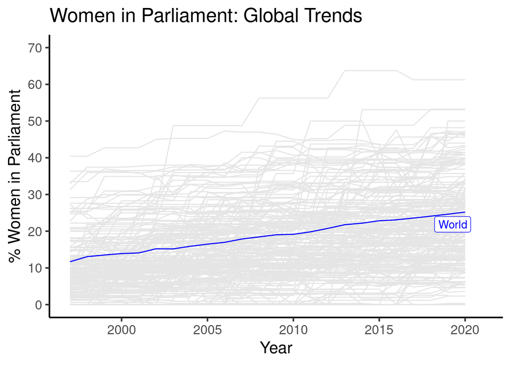

```r
WP[!is.na(Continent)] %>%
  ggplot(aes(Year, pctWiP, group = Country.Name, label = cLabel)) +
  geom_line(colour="grey90") +
  geom_line(data=WP[Country.Name=="World"], colour="blue") +
  expand_limits(x = 2021) +
  geom_label_repel(data = WP[Country.Name=="World"],
                   xlim = c(2018, 2021), colour = "Blue") +
  theme(legend.position = "none") +
  scale_x_continuous(breaks=seq(1990, 2021, 5)) +
  scale_y_continuous(limits=c(0, 70), breaks=seq(0, 70, by=10)) +
  ggtitle("Women in Parliament: Global Trends") +
  ylab("% Women in Parliament")
```

A box whisker plot is better suited to present the variation (uncertainty) over time.

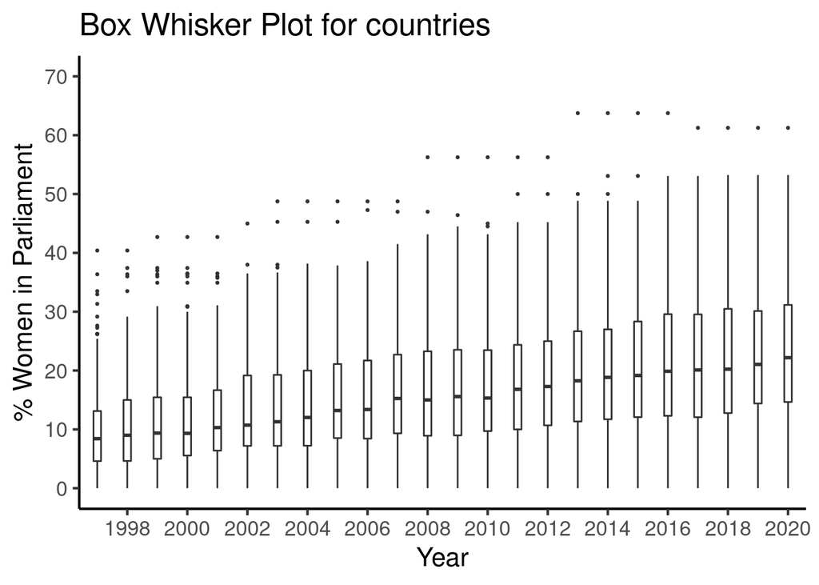

```r
WP[!is.na(Continent)] %>%
  ggplot(aes(fYear, pctWiP)) +
  geom_boxplot(width = 0.25, outlier.size = .5) +
  scale_x_discrete(breaks=seq(1990, 2020, 2)) +
  scale_y_continuous(limits=c(0, 70), breaks=seq(0, 70, by=10)) +
  ggtitle("Box Whisker Plot for countries") +
  ylab("% Women in Parliament") +
  xlab("Year")
```

### Continents

We can look at the global trends by continent for comparison.

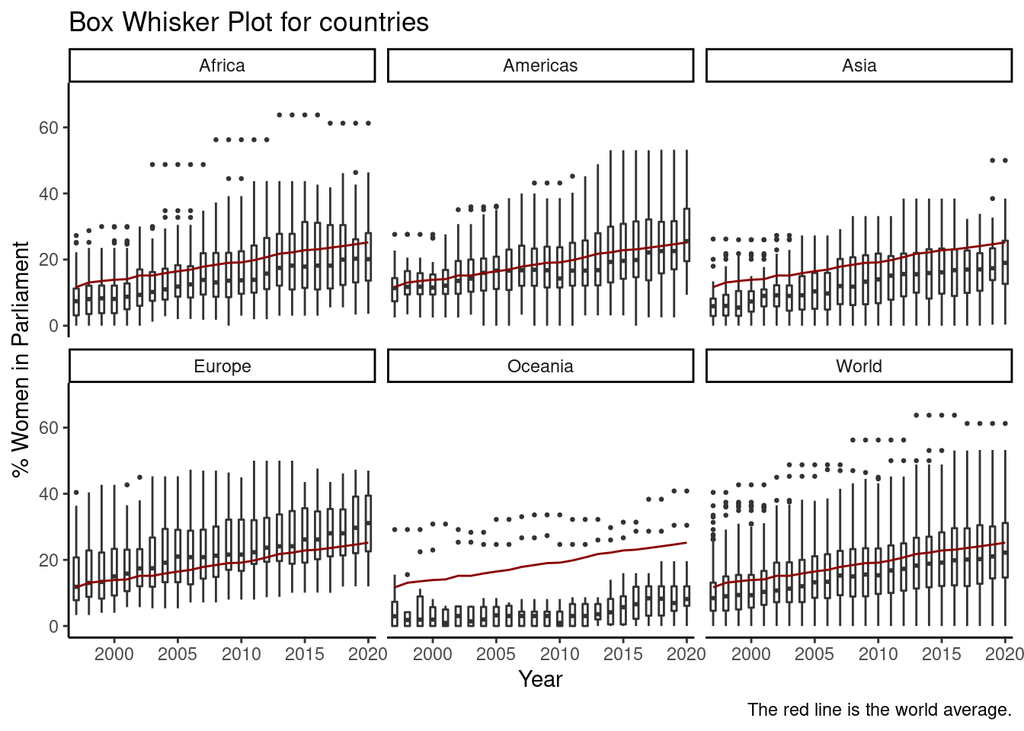

```r
# First add observations for "World" as a continent.
wWP <- rbindlist(list(WP[!is.na(Continent)],
                 WP[!is.na(Continent)][, Continent:="World"]))

wWP %>%
  ggplot(aes(fYear, pctWiP)) +
  geom_boxplot(width = 0.4, outlier.size = .5) +
  geom_line(data = WP[Country.Name=="World"][
    , .(fYear, pctWiP, Country.Name)],
    aes(fYear, y = pctWiP, group = Country.Name), colour = "darkred") +
  scale_x_discrete(breaks=seq(1990, 2020, 5)) +
  scale_y_continuous(limits=c(0, 70), breaks=seq(0, 70, by=20)) +
  facet_wrap(~Continent) +
  ggtitle("Box Whisker Plot for countries") +
  ylab("% Women in Parliament") +
  xlab("Year")+
  theme_classic(base_size=11) +
  labs(caption = "The red line is the world average.")
```

**Interpretation**

Although the world average is going up there is still large variation between countries. The interpretation by continent is similar. Note that in earlier years fewer countries provided data so there is likely to be some bais in the plots above.

# Conclusions

In 2020, globally there were 25.2% women in parliament, i.e, for every woman in parliament there was 3.0 men in parliament. Whichever way we look at the data the conclusions is that, in general, the percentage of women in parliament is increasing but that gender parity in most parliaments is still far-off.